# REGRESIÓN LOGÍSTICA (CLASE)

```r
# Cargar librerias
library(tidyverse) # ETL
library(caret) # Modelos
library(plotly) # Graficos interactivos
library(rattle) # Dataset del clima en australia

data("weatherAUS")

# Primera vista de los datos
head(weatherAUS)
```

| Date | Location | MinTemp | MaxTemp | Rainfall | Evaporation | Sunshine | WindGustDir | WindGustSpeed | WindDir9am | WindDir3pm | WindSpeed9am | WindSpeed3pm | Humidity9am | Humidity3pm | Pressure9am | Pressure3pm | Cloud9am | Cloud3pm | Temp9am | Temp3pm | RainToday | RISK_MM | RainTomorrow |
| --- | --- | --- | --- | --- | --- | --- | --- | --- | --- | --- | --- | --- | --- | --- | --- | --- | --- | --- | --- | --- | --- | --- | --- |
| 2008-12-01 | Albury | 13.4 | 22.9 | 0.6 | NA | NA | W | 44 | W | WNW | 20 | 24 | 71 | 22 | 1007.7 | 1007.1 | 8 | NA | 16.9 | 21.8 | No | 0.0 | No |
| 2008-12-02 | Albury | 7.4 | 25.1 | 0.0 | NA | NA | WNW | 44 | NNW | WSW | 4 | 22 | 44 | 25 | 1010.6 | 1007.8 | NA | NA | 17.2 | 24.3 | No | 0.0 | No |
| 2008-12-03 | Albury | 12.9 | 25.7 | 0.0 | NA | NA | WSW | 46 | W | WSW | 19 | 26 | 38 | 30 | 1007.6 | 1008.7 | NA | 2 | 21.0 | 23.2 | No | 0.0 | No |
| 2008-12-04 | Albury | 9.2 | 28.0 | 0.0 | NA | NA | NE | 24 | SE | E | 11 | 9 | 45 | 16 | 1017.6 | 1012.8 | NA | NA | 18.1 | 26.5 | No | 1.0 | No |
| 2008-12-05 | Albury | 17.5 | 32.3 | 1.0 | NA | NA | W | 41 | ENE | NW | 7 | 20 | 82 | 33 | 1010.8 | 1006.0 | 7 | 8 | 17.8 | 29.7 | No | 0.2 | No |
| 2008-12-06 | Albury | 14.6 | 29.7 | 0.2 | NA | NA | WNW | 56 | W | W | 19 | 24 | 55 | 23 | 1009.2 | 1005.4 | NA | NA | 20.6 | 28.9 | No | 0.0 | No |

*Análisis Exploratorio*

```r
# Forma del dataset
dim(weatherAUS)
```

```
[1] 208495     24
```

```r
# Columnas del dataset
names(weatherAUS)
```

```
 [1] "Date"          "Location"      "MinTemp"       "MaxTemp"
 [5] "Rainfall"      "Evaporation"   "Sunshine"      "WindGustDir"
 [9] "WindGustSpeed" "WindDir9am"    "WindDir3pm"    "WindSpeed9am"
[13] "WindSpeed3pm"  "Humidity9am"   "Humidity3pm"   "Pressure9am"
[17] "Pressure3pm"   "Cloud9am"      "Cloud3pm"      "Temp9am"
[21] "Temp3pm"       "RainToday"     "RISK_MM"       "RainTomorrow"
```

En la documentación del dataset dice que debemos eliminar “RISK_MM”, por lo que lo hacemos de la siguiente manera:

```r
weatherAUS <- weatherAUS %>%
  select(-RISK_MM)

names(weatherAUS)
```

```
 [1] "Date"          "Location"      "MinTemp"       "MaxTemp"
 [5] "Rainfall"      "Evaporation"   "Sunshine"      "WindGustDir"
 [9] "WindGustSpeed" "WindDir9am"    "WindDir3pm"    "WindSpeed9am"
[13] "WindSpeed3pm"  "Humidity9am"   "Humidity3pm"   "Pressure9am"
[17] "Pressure3pm"   "Cloud9am"      "Cloud3pm"      "Temp9am"
[21] "Temp3pm"       "RainToday"     "RainTomorrow"
```

```r
# Estructura del dataset
str(weatherAUS)
```

```
tibble [208,495 × 23] (S3: tbl_df/tbl/data.frame)
 $ Date         : Date[1:208495], format: "2008-12-01" "2008-12-02" ...
 $ Location     : chr [1:208495] "Albury" "Albury" "Albury" "Albury" ...
 $ MinTemp      : num [1:208495] 13.4 7.4 12.9 9.2 17.5 14.6 14.3 7.7 9.7 13.1 ...
 $ MaxTemp      : num [1:208495] 22.9 25.1 25.7 28 32.3 29.7 25 26.7 31.9 30.1 ...
 $ Rainfall     : num [1:208495] 0.6 0 0 0 1 0.2 0 0 0 1.4 ...
 $ Evaporation  : num [1:208495] NA NA NA NA NA NA NA NA NA NA ...
 $ Sunshine     : num [1:208495] NA NA NA NA NA NA NA NA NA NA ...
 $ WindGustDir  : Ord.factor w/ 16 levels "N"<"NNE"<"NE"<..: 13 14 12 3 13 14 13 13 16 13 ...
 $ WindGustSpeed: num [1:208495] 44 44 46 24 41 56 50 35 80 28 ...
 $ WindDir9am   : Ord.factor w/ 16 levels "N"<"NNE"<"NE"<..: 13 16 13 7 4 13 11 8 7 9 ...
 $ WindDir3pm   : Ord.factor w/ 16 levels "N"<"NNE"<"NE"<..: 14 12 12 5 15 13 13 13 15 8 ...
 $ WindSpeed9am : num [1:208495] 20 4 19 11 7 19 20 6 7 15 ...
 $ WindSpeed3pm : num [1:208495] 24 22 26 9 20 24 24 17 28 11 ...
 $ Humidity9am  : int [1:208495] 71 44 38 45 82 55 49 48 42 58 ...
 $ Humidity3pm  : int [1:208495] 22 25 30 16 33 23 19 19 9 27 ...
 $ Pressure9am  : num [1:208495] 1008 1011 1008 1018 1011 ...
 $ Pressure3pm  : num [1:208495] 1007 1008 1009 1013 1006 ...
 $ Cloud9am     : int [1:208495] 8 NA NA NA 7 NA 1 NA NA NA ...
 $ Cloud3pm     : int [1:208495] NA NA 2 NA 8 NA NA NA NA NA ...
 $ Temp9am      : num [1:208495] 16.9 17.2 21 18.1 17.8 20.6 18.1 16.3 18.3 20.1 ...
 $ Temp3pm      : num [1:208495] 21.8 24.3 23.2 26.5 29.7 28.9 24.6 25.5 30.2 28.2 ...
 $ RainToday    : Factor w/ 2 levels "No","Yes": 1 1 1 1 1 1 1 1 1 2 ...
 $ RainTomorrow : Factor w/ 2 levels "No","Yes": 1 1 1 1 1 1 1 1 2 1 ...
```

```r
# Resumen estadistico de columnas
summary(weatherAUS)
```

```
      Date              Location            MinTemp         MaxTemp
 Min.   :2007-11-01   Length:208495      Min.   :-8.70   Min.   :-4.10
 1st Qu.:2012-01-18   Class :character   1st Qu.: 7.50   1st Qu.:18.00
 Median :2015-03-07   Mode  :character   Median :11.90   Median :22.70
 Mean   :2015-07-15                      Mean   :12.08   Mean   :23.25
 3rd Qu.:2019-03-11                      3rd Qu.:16.80   3rd Qu.:28.30
 Max.   :2022-02-27                      Max.   :33.90   Max.   :48.90
                                         NA's   :3285    NA's   :3085
    Rainfall        Evaporation        Sunshine       WindGustDir
 Min.   :  0.000   Min.   :  0.00   Min.   : 0.00    W      : 14122
 1st Qu.:  0.000   1st Qu.:  2.60   1st Qu.: 4.90    SE     : 13364
 Median :  0.000   Median :  4.80   Median : 8.50    E      : 13074
 Mean   :  2.296   Mean   :  5.52   Mean   : 7.64    S      : 13019
 3rd Qu.:  0.600   3rd Qu.:  7.40   3rd Qu.:10.60    WSW    : 12959
 Max.   :474.000   Max.   :138.70   Max.   :14.50    (Other):126191
 NA's   :5930      NA's   :109530   NA's   :118202   NA's   : 15766
 WindGustSpeed      WindDir9am       WindDir3pm      WindSpeed9am
 Min.   :  2.00   N      : 16321   SE     : 15053   Min.   : 0.00
 1st Qu.: 31.00   SE     : 13367   W      : 14361   1st Qu.: 7.00
 Median : 39.00   E      : 13304   S      : 13797   Median :13.00
 Mean   : 40.14   SSE    : 13065   WSW    : 13654   Mean   :14.07
 3rd Qu.: 48.00   S      : 12295   SSE    : 13001   3rd Qu.:19.00
 Max.   :135.00   (Other):124008   (Other):129961   Max.   :87.00
 NA's   :15659    NA's   : 16135   NA's   :  8668   NA's   :3842
  WindSpeed3pm    Humidity9am      Humidity3pm      Pressure9am
 Min.   : 0.00   Min.   :  0.00   Min.   :  0.00   Min.   : 979.1
 1st Qu.:13.00   1st Qu.: 57.00   1st Qu.: 36.00   1st Qu.:1012.9
 Median :19.00   Median : 70.00   Median : 52.00   Median :1017.6
 Mean   :18.65   Mean   : 68.64   Mean   : 51.11   Mean   :1017.7
 3rd Qu.:24.00   3rd Qu.: 83.00   3rd Qu.: 66.00   3rd Qu.:1022.5
 Max.   :87.00   Max.   :100.00   Max.   :100.00   Max.   :1041.1
 NA's   :7254    NA's   :4351     NA's   :8329     NA's   :23000
  Pressure3pm        Cloud9am        Cloud3pm        Temp9am
 Min.   : 978.9   Min.   :0.00    Min.   :0.00    Min.   :-6.20
 1st Qu.:1010.4   1st Qu.:1.00    1st Qu.:2.00    1st Qu.:12.20
 Median :1015.2   Median :6.00    Median :5.00    Median :16.70
 Mean   :1015.3   Mean   :4.62    Mean   :4.62    Mean   :16.94
 3rd Qu.:1020.1   3rd Qu.:7.00    3rd Qu.:7.00    3rd Qu.:21.50
 Max.   :1040.1   Max.   :9.00    Max.   :9.00    Max.   :40.20
 NA's   :22981    NA's   :89076   NA's   :95092   NA's   :3310
    Temp3pm      RainToday     RainTomorrow
 Min.   :-5.10   No  :158288   No  :158277
 1st Qu.:16.60   Yes : 44277   Yes : 44289
 Median :21.20   NA's:  5930   NA's:  5929
 Mean   :21.72
 3rd Qu.:26.50
 Max.   :48.20
 NA's   :7310
```

```r
# Valores nulos
sum(is.na(weatherAUS))
```

```
[1] 572664
```

```r
# Valores nulos por columna
colSums(is.na(weatherAUS))
```

```
         Date      Location       MinTemp       MaxTemp      Rainfall
            0             0          3285          3085          5930
  Evaporation      Sunshine   WindGustDir WindGustSpeed    WindDir9am
       109530        118202         15766         15659         16135
   WindDir3pm  WindSpeed9am  WindSpeed3pm   Humidity9am   Humidity3pm
         8668          3842          7254          4351          8329
  Pressure9am   Pressure3pm      Cloud9am      Cloud3pm       Temp9am
        23000         22981         89076         95092          3310
      Temp3pm     RainToday  RainTomorrow
         7310          5930          5929
```

```r
# Valores de la columna date
length(unique(weatherAUS$Date))
```

```
[1] 4745
```

Vemos que DATE tiene alta cardinalidad, lo que puede ser un problema a la hora de modelar, por lo que la modificaremos.

```r
library(lubridate) # Cargamos lubridate para manejar fechas facilmente

weatherAUS$Year <- year(weatherAUS$Date) # Año

weatherAUS$Month <- month(weatherAUS$Date) # Mes

weatherAUS$Day <- day(weatherAUS$Date) # Día

head(weatherAUS) # Verificamos los cambios
```

| Date | Location | MinTemp | MaxTemp | Rainfall | Evaporation | Sunshine | WindGustDir | WindGustSpeed | WindDir9am | WindDir3pm | WindSpeed9am | WindSpeed3pm | Humidity9am | Humidity3pm | Pressure9am | Pressure3pm | Cloud9am | Cloud3pm | Temp9am | Temp3pm | RainToday | RainTomorrow | Year | Month | Day |
| --- | --- | --- | --- | --- | --- | --- | --- | --- | --- | --- | --- | --- | --- | --- | --- | --- | --- | --- | --- | --- | --- | --- | --- | --- | --- |
| 2008-12-01 | Albury | 13.4 | 22.9 | 0.6 | NA | NA | W | 44 | W | WNW | 20 | 24 | 71 | 22 | 1007.7 | 1007.1 | 8 | NA | 16.9 | 21.8 | No | No | 2008 | 12 | 1 |
| 2008-12-02 | Albury | 7.4 | 25.1 | 0.0 | NA | NA | WNW | 44 | NNW | WSW | 4 | 22 | 44 | 25 | 1010.6 | 1007.8 | NA | NA | 17.2 | 24.3 | No | No | 2008 | 12 | 2 |
| 2008-12-03 | Albury | 12.9 | 25.7 | 0.0 | NA | NA | WSW | 46 | W | WSW | 19 | 26 | 38 | 30 | 1007.6 | 1008.7 | NA | 2 | 21.0 | 23.2 | No | No | 2008 | 12 | 3 |
| 2008-12-04 | Albury | 9.2 | 28.0 | 0.0 | NA | NA | NE | 24 | SE | E | 11 | 9 | 45 | 16 | 1017.6 | 1012.8 | NA | NA | 18.1 | 26.5 | No | No | 2008 | 12 | 4 |
| 2008-12-05 | Albury | 17.5 | 32.3 | 1.0 | NA | NA | W | 41 | ENE | NW | 7 | 20 | 82 | 33 | 1010.8 | 1006.0 | 7 | 8 | 17.8 | 29.7 | No | No | 2008 | 12 | 5 |
| 2008-12-06 | Albury | 14.6 | 29.7 | 0.2 | NA | NA | WNW | 56 | W | W | 19 | 24 | 55 | 23 | 1009.2 | 1005.4 | NA | NA | 20.6 | 28.9 | No | No | 2008 | 12 | 6 |

```r
# Eliminamos Date del dataset
weatherAUS <- weatherAUS %>%
  select(-Date)

head(weatherAUS, 2)
```

| Location | MinTemp | MaxTemp | Rainfall | Evaporation | Sunshine | WindGustDir | WindGustSpeed | WindDir9am | WindDir3pm | WindSpeed9am | WindSpeed3pm | Humidity9am | Humidity3pm | Pressure9am | Pressure3pm | Cloud9am | Cloud3pm | Temp9am | Temp3pm | RainToday | RainTomorrow | Year | Month | Day |
| --- | --- | --- | --- | --- | --- | --- | --- | --- | --- | --- | --- | --- | --- | --- | --- | --- | --- | --- | --- | --- | --- | --- | --- | --- |
| Albury | 13.4 | 22.9 | 0.6 | NA | NA | W | 44 | W | WNW | 20 | 24 | 71 | 22 | 1007.7 | 1007.1 | 8 | NA | 16.9 | 21.8 | No | No | 2008 | 12 | 1 |
| Albury | 7.4 | 25.1 | 0.0 | NA | NA | WNW | 44 | NNW | WSW | 4 | 22 | 44 | 25 | 1010.6 | 1007.8 | NA | NA | 17.2 | 24.3 | No | No | 2008 | 12 | 2 |

```r
# Variables categóricas
categoricas <- c()
for(i in 1:ncol(weatherAUS)){
  if (is.character(weatherAUS[[i]]) || is.factor(weatherAUS[[i]])){
    categoricas <- c(categoricas, names(weatherAUS)[i])
  }
}
cat("Cantidad de columnas categóricas:", length(categoricas), "\n")
```

```
Cantidad de columnas categóricas: 6
```

```r
cat("Columnas categóricas:", categoricas)
```

```
Columnas categóricas: Location WindGustDir WindDir9am WindDir3pm RainToday RainTomorrow
```

```r
# Valores nulos de columnas categóricas
colSums(is.na(weatherAUS[, categoricas]))
```

```
    Location  WindGustDir   WindDir9am   WindDir3pm    RainToday RainTomorrow
           0        15766        16135         8668         5930         5929
```

```r
# Eliminamos los NA de la variable target
weatherAUS <- drop_na(weatherAUS, RainTomorrow)

weatherAUS
```

| Location | MinTemp | MaxTemp | Rainfall | Evaporation | Sunshine | WindGustDir | WindGustSpeed | WindDir9am | WindDir3pm | WindSpeed9am | WindSpeed3pm | Humidity9am | Humidity3pm | Pressure9am | Pressure3pm | Cloud9am | Cloud3pm | Temp9am | Temp3pm | RainToday | RainTomorrow | Year | Month | Day |
| --- | --- | --- | --- | --- | --- | --- | --- | --- | --- | --- | --- | --- | --- | --- | --- | --- | --- | --- | --- | --- | --- | --- | --- | --- |
| Albury | 13.4 | 22.9 | 0.6 | NA | NA | W | 44 | W | WNW | 20 | 24 | 71 | 22 | 1007.7 | 1007.1 | 8 | NA | 16.9 | 21.8 | No | No | 2008 | 12 | 1 |
| Albury | 7.4 | 25.1 | 0.0 | NA | NA | WNW | 44 | NNW | WSW | 4 | 22 | 44 | 25 | 1010.6 | 1007.8 | NA | NA | 17.2 | 24.3 | No | No | 2008 | 12 | 2 |
| Albury | 12.9 | 25.7 | 0.0 | NA | NA | WSW | 46 | W | WSW | 19 | 26 | 38 | 30 | 1007.6 | 1008.7 | NA | 2 | 21.0 | 23.2 | No | No | 2008 | 12 | 3 |
| Albury | 9.2 | 28.0 | 0.0 | NA | NA | NE | 24 | SE | E | 11 | 9 | 45 | 16 | 1017.6 | 1012.8 | NA | NA | 18.1 | 26.5 | No | No | 2008 | 12 | 4 |
| Albury | 17.5 | 32.3 | 1.0 | NA | NA | W | 41 | ENE | NW | 7 | 20 | 82 | 33 | 1010.8 | 1006.0 | 7 | 8 | 17.8 | 29.7 | No | No | 2008 | 12 | 5 |
| Albury | 14.6 | 29.7 | 0.2 | NA | NA | WNW | 56 | W | W | 19 | 24 | 55 | 23 | 1009.2 | 1005.4 | NA | NA | 20.6 | 28.9 | No | No | 2008 | 12 | 6 |
| Albury | 14.3 | 25.0 | 0.0 | NA | NA | W | 50 | SW | W | 20 | 24 | 49 | 19 | 1009.6 | 1008.2 | 1 | NA | 18.1 | 24.6 | No | No | 2008 | 12 | 7 |
| Albury | 7.7 | 26.7 | 0.0 | NA | NA | W | 35 | SSE | W | 6 | 17 | 48 | 19 | 1013.4 | 1010.1 | NA | NA | 16.3 | 25.5 | No | No | 2008 | 12 | 8 |
| Albury | 9.7 | 31.9 | 0.0 | NA | NA | NNW | 80 | SE | NW | 7 | 28 | 42 | 9 | 1008.9 | 1003.6 | NA | NA | 18.3 | 30.2 | No | Yes | 2008 | 12 | 9 |
| Albury | 13.1 | 30.1 | 1.4 | NA | NA | W | 28 | S | SSE | 15 | 11 | 58 | 27 | 1007.0 | 1005.7 | NA | NA | 20.1 | 28.2 | Yes | No | 2008 | 12 | 10 |

[output cut: 990 more lines]

```r
# Vistazo de como quedaron los NA
colSums(is.na(weatherAUS[, categoricas]))
```

```
    Location  WindGustDir   WindDir9am   WindDir3pm    RainToday RainTomorrow
           0        14114        15275         7973         1941            0
```

```r
# Valores únicos de las columnas categóricas
sapply(weatherAUS[, categoricas], unique)
```

```
$Location
 [1] "Albury"           "BadgerysCreek"    "Cobar"            "CoffsHarbour"
 [5] "Moree"            "Newcastle"        "NorahHead"        "NorfolkIsland"
 [9] "Penrith"          "Richmond"         "Sydney"           "SydneyAirport"
[13] "WaggaWagga"       "Williamtown"      "Wollongong"       "Canberra"
[17] "Tuggeranong"      "MountGinini"      "Ballarat"         "Bendigo"
[21] "Sale"             "MelbourneAirport" "Melbourne"        "Mildura"
[25] "Nhil"             "Portland"         "Watsonia"         "Dartmoor"
[29] "Brisbane"         "Cairns"           "GoldCoast"        "Townsville"
[33] "Adelaide"         "MountGambier"     "Nuriootpa"        "Woomera"
[37] "Albany"           "Witchcliffe"      "PearceRAAF"       "PerthAirport"
[41] "Perth"            "SalmonGums"       "Walpole"          "Hobart"
[45] "Launceston"       "AliceSprings"     "Darwin"           "Katherine"
[49] "Uluru"

$WindGustDir
 [1] W    WNW  WSW  NE   NNW  N    NNE  SW   ENE  SSE  S    NW   SE   ESE  <NA>
[16] E    SSW
16 Levels: N < NNE < NE < ENE < E < ESE < SE < SSE < S < SSW < SW < ... < NNW

$WindDir9am
 [1] W    NNW  SE   ENE  SW   SSE  S    NE   <NA> SSW  N    WSW  ESE  E    NW
[16] WNW  NNE
16 Levels: N < NNE < NE < ENE < E < ESE < SE < SSE < S < SSW < SW < ... < NNW

$WindDir3pm
 [1] WNW  WSW  E    NW   W    SSE  ESE  ENE  NNW  SSW  SW   SE   N    S    NNE
[16] <NA> NE
16 Levels: N < NNE < NE < ENE < E < ESE < SE < SSE < S < SSW < SW < ... < NNW

$RainToday
[1] No   Yes  <NA>
Levels: No Yes

$RainTomorrow
[1] No  Yes
Levels: No Yes
```

```r
# Cardinalidad de las demás columnas categóricas
sapply(weatherAUS[, categoricas], function(x) length(unique(x)))
```

```
    Location  WindGustDir   WindDir9am   WindDir3pm    RainToday RainTomorrow
          49           17           17           17            3            2
```

```r
# Apariciones de cada valor único
sapply(weatherAUS[, categoricas], table)
```

```
$Location

        Adelaide           Albany           Albury     AliceSprings
            3810             4285             4314             4327
   BadgerysCreek         Ballarat          Bendigo         Brisbane
            4210             4317             4325             4413
          Cairns         Canberra            Cobar     CoffsHarbour
            4164             4726             4298             4261
        Dartmoor           Darwin        GoldCoast           Hobart
            4229             4501             4251             4482
       Katherine       Launceston        Melbourne MelbourneAirport
            1648             4337             3835             4318
         Mildura            Moree     MountGambier      MountGinini
            4294             4164             4317             4014
       Newcastle             Nhil        NorahHead    NorfolkIsland
            3883             2780             4222             4236
       Nuriootpa       PearceRAAF          Penrith            Perth
            4307             3979             4264             4494
    PerthAirport         Portland         Richmond             Sale
            4317             4281             4259             4301
      SalmonGums           Sydney    SydneyAirport       Townsville
            4198             4639             4314             4334
     Tuggeranong            Uluru       WaggaWagga          Walpole
            4298             2822             4040             4035
        Watsonia      Williamtown      Witchcliffe       Wollongong
            4300             3897             4015             4228
         Woomera
            4283

$WindGustDir

    N   NNE    NE   ENE     E   ESE    SE   SSE     S   SSW    SW   WSW     W
12547  9327 10176 11437 12662 10431 13032 12491 12750 12638 12391 12687 13882
  WNW    NW   NNW
11424 11252  9325

$WindDir9am

    N   NNE    NE   ENE     E   ESE    SE   SSE     S   SSW    SW   WSW     W
15836 11417 10671 11017 12945 11068 12972 12764 12060 10799 11731  9515 11493
  WNW    NW   NNW
10318 11788 10897

$WindDir3pm

    N   NNE    NE   ENE     E   ESE    SE   SSE     S   SSW    SW   WSW     W
12080  9389 11681 11009 11431 11745 14634 12643 13404 11587 12699 13311 13993
  WNW    NW   NNW
12342 11825 10820

$RainToday

    No    Yes
156903  43722

$RainTomorrow

    No    Yes
158277  44289
```

```r
# Variables numéricas
numericas <- c()
for(i in 1:ncol(weatherAUS)){
  if (is.numeric(weatherAUS[[i]])){
    numericas <- c(numericas, names(weatherAUS)[i])
  }
}

cat("Cantidad de columnas numéricas:", length(numericas), "\n")
```

```
Cantidad de columnas numéricas: 19
```

```r
cat("Columnas numéricas:", numericas)
```

```
Columnas numéricas: MinTemp MaxTemp Rainfall Evaporation Sunshine WindGustSpeed WindSpeed9am WindSpeed3pm Humidity9am Humidity3pm Pressure9am Pressure3pm Cloud9am Cloud3pm Temp9am Temp3pm Year Month Day
```

```r
# Valores nulos de columnas numéricas
colSums(is.na(weatherAUS[, numericas]))
```

```
      MinTemp       MaxTemp      Rainfall   Evaporation      Sunshine
         1082           686          1941        105049        113609
WindGustSpeed  WindSpeed9am  WindSpeed3pm   Humidity9am   Humidity3pm
        14011          3236          6595          2192          6095
  Pressure9am   Pressure3pm      Cloud9am      Cloud3pm       Temp9am
        21675         21669         84693         90603          1170
      Temp3pm          Year         Month           Day
         5091             0             0             0
```

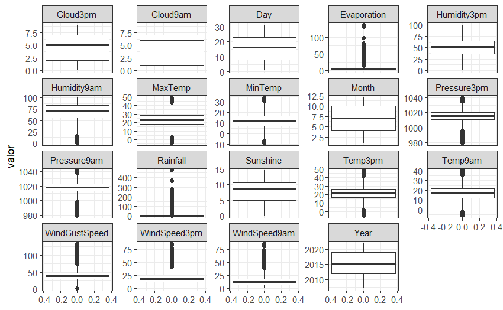

```r
# Analizar presencia de outliers
weatherAUS %>%
  pivot_longer(cols=numericas, names_to="caracteristica", values_to="valor") %>%
  ggplot()+
  aes(y=valor) +
  geom_boxplot() +
  facet_wrap(~caracteristica, scales="free_y") +
  theme_bw()
```

Vemos que existen muchos outliers en las columnas Rainfall, Evaporation, WindGustSpeed, WindSpeed3pm, WindSpeed9am

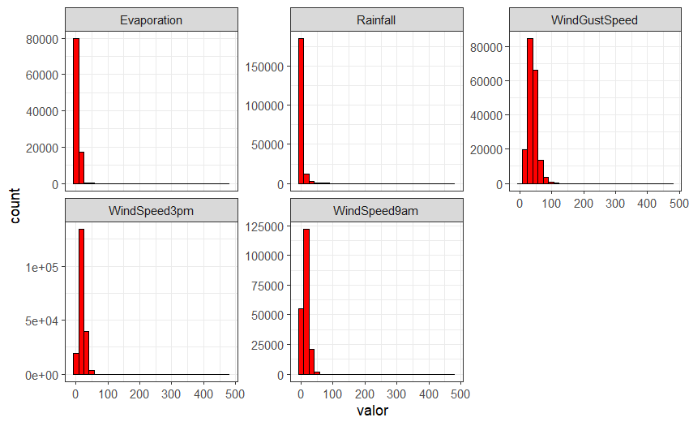

```r
outliers <- c("Rainfall", "Evaporation", "WindGustSpeed", "WindSpeed3pm", "WindSpeed9am")
# Analizar distribución de columnas con outliers
weatherAUS %>%
  select(outliers) %>%
  gather(key="variable", value="valor") %>%
  ggplot()+
  aes(x=valor)+
  geom_histogram(color="black", fill="red", bins=30) +
  facet_wrap(~variable, scales="free_y") +
  theme_bw()
```

Vemos que las distribuciones están sesgadas positivamente (cola larga a la derecha). Buscaremos outliers con el IQR.

```r
# Outliers en Rainfall
quantiles <- quantile(weatherAUS$Rainfall, c(0.25, 0.75), na.rm=T)
iqr <- IQR(weatherAUS$Rainfall, na.rm=T)
limite_inf <- quantiles[1] - iqr * 1.5
limite_sup <- quantiles[2] + iqr * 1.5
print(limite_inf)
```

```
 25%
-0.9
```

```r
print(limite_sup)
```

```
75%
1.5
```

```r
print(min(weatherAUS$Rainfall, na.rm=T))
```

```
[1] 0
```

```r
print(max(weatherAUS$Rainfall, na.rm=T))
```

```
[1] 474
```

Para la columna “Rainfall” los valores menores a -0.9 y mayores a 1.5 son outliers. El minimo de columna es 0 y el maximo es 474 por lo que los outliers son los valores mayores a 1.5.

```r
# Outliers en Evaporation
quantiles <- quantile(weatherAUS$Evaporation, c(0.25, 0.75), na.rm=T)
iqr <- IQR(weatherAUS$Evaporation, na.rm=T)
limite_inf <- quantiles[1] - iqr * 1.5
limite_sup <- quantiles[2] + iqr * 1.5
print(limite_inf)
```

```
  25%
-4.35
```

```r
print(limite_sup)
```

```
  75%
14.45
```

```r
print(min(weatherAUS$Evaporation, na.rm=T))
```

```
[1] 0
```

```r
print(max(weatherAUS$Evaporation, na.rm=T))
```

```
[1] 138.7
```

Para la columna “Evaporation” observamos que los valores menores a -4.35 y mayores a 14.45 son outliers. Como el minimo de columna es 0, los outliers son los valores mayores a 14.45.

```r
# Outliers en WindGustSpeed
quantiles <- quantile(weatherAUS$WindGustSpeed, c(0.25, 0.75), na.rm=T)
iqr <- IQR(weatherAUS$WindGustSpeed, na.rm=T)
limite_inf <- quantiles[1] - iqr * 1.5
limite_sup <- quantiles[2] + iqr * 1.5
print(limite_inf)
```

```
25%
5.5
```

```r
print(limite_sup)
```

```
 75%
73.5
```

```r
print(min(weatherAUS$WindGustSpeed, na.rm=T))
```

```
[1] 2
```

```r
print(max(weatherAUS$WindGustSpeed, na.rm=T))
```

```
[1] 135
```

Para la columna “WindGustSpeed” observamos que los valores menores a 5.5 y mayores a 73.5 son outliers. Siendo el minimo 2 y el maximo 135, observamos que hay outliers inferiores a 5.5 y superiores a 73.5.

```r
# Outliers en WindSpeed3pm
quantiles <- quantile(weatherAUS$WindSpeed3pm, c(0.25, 0.75), na.rm=T)
iqr <- IQR(weatherAUS$WindSpeed3pm, na.rm=T)
limite_inf <- quantiles[1] - iqr * 1.5
limite_sup <- quantiles[2] + iqr * 1.5
print(limite_inf)
```

```
 25%
-3.5
```

```r
print(limite_sup)
```

```
 75%
40.5
```

```r
print(min(weatherAUS$WindSpeed3pm, na.rm=T))
```

```
[1] 0
```

```r
print(max(weatherAUS$WindSpeed3pm, na.rm=T))
```

```
[1] 87
```

Para la columna “WindSpeed3pm” observamos que los valores menores a -3.5 y mayores a 40.5 son outliers. Siendo el minimo 0 y el maximo 87, observamos que los outliers son los valores mayores a 40.5.

```r
# Outliers en WindSpeed9am
quantiles <- quantile(weatherAUS$WindSpeed9am, c(0.25, 0.75), na.rm=T)
iqr <- IQR(weatherAUS$WindSpeed9am, na.rm=T)
limite_inf <- quantiles[1] - iqr * 1.5
limite_sup <- quantiles[2] + iqr * 1.5
print(limite_inf)
```

```
25%
-11
```

```r
print(limite_sup)
```

```
75%
 37
```

```r
print(min(weatherAUS$WindSpeed9am, na.rm=T))
```

```
[1] 0
```

```r
print(max(weatherAUS$WindSpeed9am, na.rm=T))
```

```
[1] 87
```

Para la columna “WindSpeed9am” observamos que los valores menores a -11 y mayores a 37 son outliers. Siendo el minimo 0 y el maximo 87, observamos que los outliers son los valores mayores a 37.

```r
# Features y target
X <- weatherAUS %>%
  select(-RainTomorrow)

y <- weatherAUS$RainTomorrow
```

Como hay outliers imputaremos los NA con la mediana para las variables numericas y con la moda para las variables categoricas/factores.

```r
library(DescTools) # Usar función Mode
X <- X %>%
  mutate(across(where(is.numeric), ~ifelse(is.na(.), median(., na.rm=T), .))) %>%
  mutate(across(where(is.factor), ~ifelse(is.na(.), Mode(., na.rm=T), .)))
# Chequeamos que todo funcione
colSums(is.na(X))
```

```
     Location       MinTemp       MaxTemp      Rainfall   Evaporation
            0             0             0             0             0
     Sunshine   WindGustDir WindGustSpeed    WindDir9am    WindDir3pm
            0             0             0             0             0
 WindSpeed9am  WindSpeed3pm   Humidity9am   Humidity3pm   Pressure9am
            0             0             0             0             0
  Pressure3pm      Cloud9am      Cloud3pm       Temp9am       Temp3pm
            0             0             0             0             0
    RainToday          Year         Month           Day
            0             0             0             0
```

```r
# Train y test sets
indice <- createDataPartition(y, p=0.7, list=F)

X_train <- X[indice, ]
y_train <- y[indice]
X_test <- X[-indice, ]
y_test <- y[-indice]
```

*Feature Engineering*

```r
print(dim(X_train))
```

```
[1] 141797     24
```

```r
print(dim(X_test))
```

```
[1] 60769    24
```

```r
print(sum(is.na(X_train)))
```

```
[1] 0
```

```r
print(sum(is.na(X_test)))
```

```
[1] 0
```

```r
valor_maximo <- function(df, variable, top) {
  df[[variable]] <- pmin(df[[variable]], top, na.rm=T)
  return(df)
}

for (df1 in c("X_train", "X_test")) {
  assign(df1, valor_maximo(get(df1), "Rainfall", 1.5))
  assign(df1, valor_maximo(get(df1), "Evaporation", 14.45))
  assign(df1, valor_maximo(get(df1), "WindGustSpeed", 73.5))
  assign(df1, valor_maximo(get(df1), "WindSpeed9am", 37))
  assign(df1, valor_maximo(get(df1), "WindSpeed3pm", 40.5))
}

head(X_train)
```

| Location | MinTemp | MaxTemp | Rainfall | Evaporation | Sunshine | WindGustDir | WindGustSpeed | WindDir9am | WindDir3pm | WindSpeed9am | WindSpeed3pm | Humidity9am | Humidity3pm | Pressure9am | Pressure3pm | Cloud9am | Cloud3pm | Temp9am | Temp3pm | RainToday | Year | Month | Day |
| --- | --- | --- | --- | --- | --- | --- | --- | --- | --- | --- | --- | --- | --- | --- | --- | --- | --- | --- | --- | --- | --- | --- | --- |
| Albury | 13.4 | 22.9 | 0.6 | 4.8 | 8.5 | 13 | 44.0 | 13 | 14 | 20 | 24 | 71 | 22 | 1007.7 | 1007.1 | 8 | 5 | 16.9 | 21.8 | 1 | 2008 | 12 | 1 |
| Albury | 7.4 | 25.1 | 0.0 | 4.8 | 8.5 | 14 | 44.0 | 16 | 12 | 4 | 22 | 44 | 25 | 1010.6 | 1007.8 | 6 | 5 | 17.2 | 24.3 | 1 | 2008 | 12 | 2 |
| Albury | 14.6 | 29.7 | 0.2 | 4.8 | 8.5 | 14 | 56.0 | 13 | 13 | 19 | 24 | 55 | 23 | 1009.2 | 1005.4 | 6 | 5 | 20.6 | 28.9 | 1 | 2008 | 12 | 6 |
| Albury | 14.3 | 25.0 | 0.0 | 4.8 | 8.5 | 13 | 50.0 | 11 | 13 | 20 | 24 | 49 | 19 | 1009.6 | 1008.2 | 1 | 5 | 18.1 | 24.6 | 1 | 2008 | 12 | 7 |
| Albury | 7.7 | 26.7 | 0.0 | 4.8 | 8.5 | 13 | 35.0 | 8 | 13 | 6 | 17 | 48 | 19 | 1013.4 | 1010.1 | 6 | 5 | 16.3 | 25.5 | 1 | 2008 | 12 | 8 |
| Albury | 9.7 | 31.9 | 0.0 | 4.8 | 8.5 | 16 | 73.5 | 7 | 15 | 7 | 28 | 42 | 9 | 1008.9 | 1003.6 | 6 | 5 | 18.3 | 30.2 | 1 | 2008 | 12 | 9 |

```r
head(X_test)
```

| Location | MinTemp | MaxTemp | Rainfall | Evaporation | Sunshine | WindGustDir | WindGustSpeed | WindDir9am | WindDir3pm | WindSpeed9am | WindSpeed3pm | Humidity9am | Humidity3pm | Pressure9am | Pressure3pm | Cloud9am | Cloud3pm | Temp9am | Temp3pm | RainToday | Year | Month | Day |
| --- | --- | --- | --- | --- | --- | --- | --- | --- | --- | --- | --- | --- | --- | --- | --- | --- | --- | --- | --- | --- | --- | --- | --- |
| Albury | 12.9 | 25.7 | 0.0 | 4.8 | 8.5 | 12 | 46 | 13 | 12 | 19 | 26 | 38 | 30 | 1007.6 | 1008.7 | 6 | 2 | 21.0 | 23.2 | 1 | 2008 | 12 | 3 |
| Albury | 9.2 | 28.0 | 0.0 | 4.8 | 8.5 | 3 | 24 | 7 | 5 | 11 | 9 | 45 | 16 | 1017.6 | 1012.8 | 6 | 5 | 18.1 | 26.5 | 1 | 2008 | 12 | 4 |
| Albury | 17.5 | 32.3 | 1.0 | 4.8 | 8.5 | 13 | 41 | 4 | 15 | 7 | 20 | 82 | 33 | 1010.8 | 1006.0 | 7 | 8 | 17.8 | 29.7 | 1 | 2008 | 12 | 5 |
| Albury | 13.1 | 30.1 | 1.4 | 4.8 | 8.5 | 13 | 28 | 9 | 8 | 15 | 11 | 58 | 27 | 1007.0 | 1005.7 | 6 | 5 | 20.1 | 28.2 | 2 | 2008 | 12 | 10 |
| Albury | 15.9 | 21.7 | 1.5 | 4.8 | 8.5 | 2 | 31 | 3 | 4 | 15 | 13 | 89 | 91 | 1010.5 | 1004.2 | 8 | 8 | 15.9 | 17.0 | 2 | 2008 | 12 | 12 |
| Albury | 15.9 | 18.6 | 1.5 | 4.8 | 8.5 | 13 | 61 | 16 | 16 | 28 | 28 | 76 | 93 | 994.3 | 993.0 | 8 | 8 | 17.4 | 15.8 | 2 | 2008 | 12 | 13 |

```r
# Encodificar las variables categoricas/factores
library(mltools)
library(data.table)
X_train$Location <- factor(X_train$Location)
X_test$Location <- factor(X_test$Location)

X_train <- as.data.table(X_train)

X_train <- one_hot(X_train)

X_test <- as.data.table(X_test)

X_test <- one_hot(X_test)

head(X_train)
```

| Location_Adelaide | Location_Albany | Location_Albury | Location_AliceSprings | Location_BadgerysCreek | Location_Ballarat | Location_Bendigo | Location_Brisbane | Location_Cairns | Location_Canberra | Location_Cobar | Location_CoffsHarbour | Location_Dartmoor | Location_Darwin | Location_GoldCoast | Location_Hobart | Location_Katherine | Location_Launceston | Location_Melbourne | Location_MelbourneAirport | Location_Mildura | Location_Moree | Location_MountGambier | Location_MountGinini | Location_Newcastle | Location_Nhil | Location_NorahHead | Location_NorfolkIsland | Location_Nuriootpa | Location_PearceRAAF | … |
| --- | --- | --- | --- | --- | --- | --- | --- | --- | --- | --- | --- | --- | --- | --- | --- | --- | --- | --- | --- | --- | --- | --- | --- | --- | --- | --- | --- | --- | --- | --- |
| 0 | 0 | 1 | 0 | 0 | 0 | 0 | 0 | 0 | 0 | 0 | 0 | 0 | 0 | 0 | 0 | 0 | 0 | 0 | 0 | 0 | 0 | 0 | 0 | 0 | 0 | 0 | 0 | 0 | 0 | … |
| 0 | 0 | 1 | 0 | 0 | 0 | 0 | 0 | 0 | 0 | 0 | 0 | 0 | 0 | 0 | 0 | 0 | 0 | 0 | 0 | 0 | 0 | 0 | 0 | 0 | 0 | 0 | 0 | 0 | 0 | … |
| 0 | 0 | 1 | 0 | 0 | 0 | 0 | 0 | 0 | 0 | 0 | 0 | 0 | 0 | 0 | 0 | 0 | 0 | 0 | 0 | 0 | 0 | 0 | 0 | 0 | 0 | 0 | 0 | 0 | 0 | … |
| 0 | 0 | 1 | 0 | 0 | 0 | 0 | 0 | 0 | 0 | 0 | 0 | 0 | 0 | 0 | 0 | 0 | 0 | 0 | 0 | 0 | 0 | 0 | 0 | 0 | 0 | 0 | 0 | 0 | 0 | … |
| 0 | 0 | 1 | 0 | 0 | 0 | 0 | 0 | 0 | 0 | 0 | 0 | 0 | 0 | 0 | 0 | 0 | 0 | 0 | 0 | 0 | 0 | 0 | 0 | 0 | 0 | 0 | 0 | 0 | 0 | … |
| 0 | 0 | 1 | 0 | 0 | 0 | 0 | 0 | 0 | 0 | 0 | 0 | 0 | 0 | 0 | 0 | 0 | 0 | 0 | 0 | 0 | 0 | 0 | 0 | 0 | 0 | 0 | 0 | 0 | 0 | … |

```r
head(X_test)
```

| Location_Adelaide | Location_Albany | Location_Albury | Location_AliceSprings | Location_BadgerysCreek | Location_Ballarat | Location_Bendigo | Location_Brisbane | Location_Cairns | Location_Canberra | Location_Cobar | Location_CoffsHarbour | Location_Dartmoor | Location_Darwin | Location_GoldCoast | Location_Hobart | Location_Katherine | Location_Launceston | Location_Melbourne | Location_MelbourneAirport | Location_Mildura | Location_Moree | Location_MountGambier | Location_MountGinini | Location_Newcastle | Location_Nhil | Location_NorahHead | Location_NorfolkIsland | Location_Nuriootpa | Location_PearceRAAF | … |
| --- | --- | --- | --- | --- | --- | --- | --- | --- | --- | --- | --- | --- | --- | --- | --- | --- | --- | --- | --- | --- | --- | --- | --- | --- | --- | --- | --- | --- | --- | --- |
| 0 | 0 | 1 | 0 | 0 | 0 | 0 | 0 | 0 | 0 | 0 | 0 | 0 | 0 | 0 | 0 | 0 | 0 | 0 | 0 | 0 | 0 | 0 | 0 | 0 | 0 | 0 | 0 | 0 | 0 | … |
| 0 | 0 | 1 | 0 | 0 | 0 | 0 | 0 | 0 | 0 | 0 | 0 | 0 | 0 | 0 | 0 | 0 | 0 | 0 | 0 | 0 | 0 | 0 | 0 | 0 | 0 | 0 | 0 | 0 | 0 | … |
| 0 | 0 | 1 | 0 | 0 | 0 | 0 | 0 | 0 | 0 | 0 | 0 | 0 | 0 | 0 | 0 | 0 | 0 | 0 | 0 | 0 | 0 | 0 | 0 | 0 | 0 | 0 | 0 | 0 | 0 | … |
| 0 | 0 | 1 | 0 | 0 | 0 | 0 | 0 | 0 | 0 | 0 | 0 | 0 | 0 | 0 | 0 | 0 | 0 | 0 | 0 | 0 | 0 | 0 | 0 | 0 | 0 | 0 | 0 | 0 | 0 | … |
| 0 | 0 | 1 | 0 | 0 | 0 | 0 | 0 | 0 | 0 | 0 | 0 | 0 | 0 | 0 | 0 | 0 | 0 | 0 | 0 | 0 | 0 | 0 | 0 | 0 | 0 | 0 | 0 | 0 | 0 | … |
| 0 | 0 | 1 | 0 | 0 | 0 | 0 | 0 | 0 | 0 | 0 | 0 | 0 | 0 | 0 | 0 | 0 | 0 | 0 | 0 | 0 | 0 | 0 | 0 | 0 | 0 | 0 | 0 | 0 | 0 | … |

```r
# Escalar los datos
preprocesar <- preProcess(X_train, method="range")
X_train <- predict(preprocesar, X_train)
X_test <- predict(preprocesar, X_test)
```

```r
y_train <- factor(y_train)
set.seed(123)
control <- trainControl(method="cv", number=10)
modelo_lr <- train(x=X_train,
                   y=y_train,
                   method="glm",
                   family=binomial(),
                   trControl=control)
```

```r
pred_lr <- predict(modelo_lr, newdata=X_test)

conf_mat <- confusionMatrix(pred_lr, as.factor(y_test), positive="Yes")

conf_mat
```

```
Confusion Matrix and Statistics

          Reference
Prediction    No   Yes
       No  44903  6573
       Yes  2580  6713

               Accuracy : 0.8494
                 95% CI : (0.8465, 0.8522)
    No Information Rate : 0.7814
    P-Value [Acc > NIR] : < 2.2e-16

                  Kappa : 0.5057

 Mcnemar's Test P-Value : < 2.2e-16

            Sensitivity : 0.5053
            Specificity : 0.9457
         Pos Pred Value : 0.7224
         Neg Pred Value : 0.8723
             Prevalence : 0.2186
         Detection Rate : 0.1105
   Detection Prevalence : 0.1529
      Balanced Accuracy : 0.7255

       'Positive' Class : Yes
```

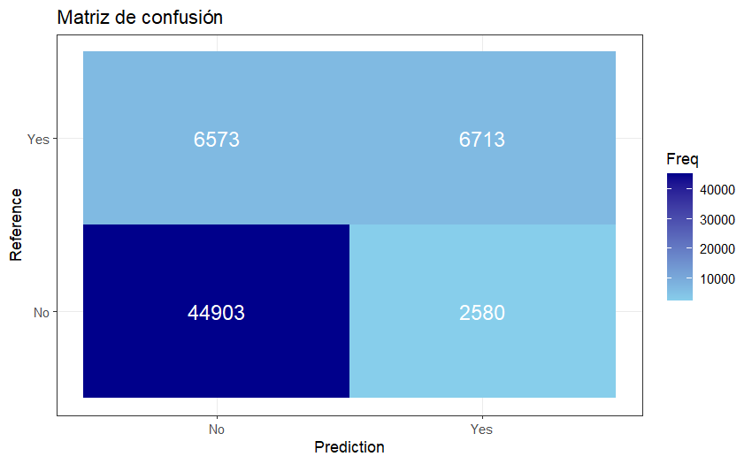

```r
mat_data <- as.data.frame(conf_mat$table)

mat_data %>%
  ggplot() +
  aes(x=Prediction, y=Reference, fill=Freq) +
  geom_tile() +
  geom_text(aes(label=Freq), color="white", size=5) +
  scale_fill_gradient(low="skyblue", high="blue4") +
  labs(title="Matriz de confusión") +
  theme_bw()
```

```r
# Overfitting?

cat("Training set score:", sum(predict(modelo_lr, X_train) == y_train) / length(y_train), "\n")
```

```
Training set score: 0.8508008
```

```r
cat("Test set score:", sum(predict(modelo_lr, X_test) == y_test) / length(y_test))
```

```
Test set score: 0.8493804
```

```r
# F1 SCORE
conf_mat$byClass["F1"]
```

```
       F1
0.5946233
```

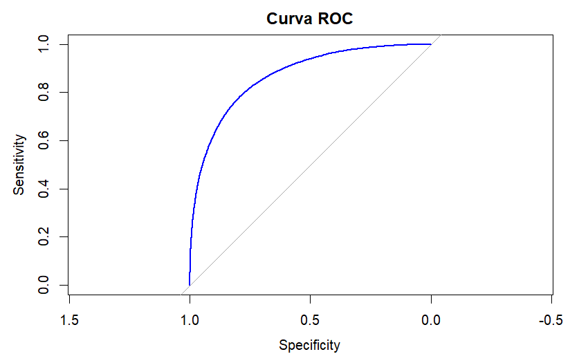

```r
# ROC y AUC
library(pROC)
probabilidades <- predict(modelo_lr, X_test, type="prob")
roc_curve <- roc(as.numeric(y_test), as.numeric(probabilidades[,2]))
plot(roc_curve, col = "blue", main = "Curva ROC")
```

```r
auc(roc_curve)
```

```
Area under the curve: 0.8698
```

Vemos que el accuracy es de 85% por lo que nuestro modelo predictivo funciona bien. No observamos diferencia significativa entre el set de entrenamiento y el set de prueba por lo que no hay signos de overfitting. El AUC es de 0.87 por lo que nuestro modelo tiene un buen nivel de predicción. En cuanto al f1 score tiene un valor de 0.6, no es malo pero hay lugar para mejora.